# Sarcasm Detection

**Acknowledgement**

Misra, Rishabh, and Prahal Arora. "Sarcasm Detection using Hybrid Neural Network." arXiv preprint arXiv:1908.07414 (2019).

**Required Files given in below link.**

https://drive.google.com/drive/folders/1xUnF35naPGU63xwRDVGc-DkZ3M8V5mMk

# Problem Description:

- Past studies in Sarcasm Detection mostly make use of Twitter datasets collected using hashtag based supervision but such datasets are noisy in terms of labels and language. Furthermore, many tweets are replies to other tweets and detecting sarcasm in these requires the availability of contextual tweets.
- In this hands-on project, the goal is to build a model to detect whether a sentence is sarcastic or not, using Bidirectional LSTMs.

# Data Description:

- News Headlines dataset for Sarcasm Detection. The dataset is collected from two news websites, theonion.com and huffingtonpost.com. This new dataset has the following advantages over the existing Twitter datasets:
- Since news headlines are written by professionals in a formal manner, there are no spelling mistakes and informal usage. This reduces the sparsity and also increases the chance of finding pre-trained embedding.
- Furthermore, since the sole purpose of TheOnion is to publish sarcastic news, we get high-quality labels with much less noise as compared to Twitter datasets. Unlike tweets that reply to other tweets, the news headlines obtained are selfcontained. This would help us in teasing apart the real sarcastic elements

# Content

- Each record consists of three attributes:
- is_sarcastic: 1 if the record is sarcastic otherwise 0
- headline: the headline of the news article
- article_link: link to the original news article. Useful in collecting supplementary data

# Reference

https://github.com/rishabhmisra/News-Headlines-Dataset-For-Sarcasm-Detection

## Install `Tensorflow2.0`

```python
#!!pip uninstall tensorflow
#!pip install tensorflow==2.0.0
```

- Installing tensorflow 2, by default if the file is executed in google colab tensorflow version is 2, so there is no need to execute this code repeatedly.

## Get Required Files from Drive

- Mounting drive and setting default project path.

```python
from google.colab import drive #import drive
drive.mount('/content/drive/') #mount drive
```

```python
proj_path = "/content/drive/My Drive/NLP/" #set project path


import os, sys #import os,sys
os.chdir(proj_path) #change directory

# Add the path to the sys.path for this session
sys.path.append(proj_path)
```

## **Reading and Exploring Data**

### Read Data "Sarcasm_Headlines_Dataset.json". Explore the data and get some insights about the data. ( 4 marks)

```python
import pandas as pd #import pandas
data = pd.read_json('Data/Sarcasm_Headlines_Dataset.json',lines = True) #read json
```

```python
print('shape of dataset:',data.shape) #print shape of data
```

```
shape of dataset: (26709, 3)
```

```python
data.head() #print head
```

|  | article_link | headline | is_sarcastic |
| --- | --- | --- | --- |
| 0 | https://www.huffingtonpost.com/entry/versace-b... | former versace store clerk sues over secret 'b... | 0 |
| 1 | https://www.huffingtonpost.com/entry/roseanne-... | the 'roseanne' revival catches up to our thorn... | 0 |
| 2 | https://local.theonion.com/mom-starting-to-fea... | mom starting to fear son's web series closest ... | 1 |
| 3 | https://politics.theonion.com/boehner-just-wan... | boehner just wants wife to listen, not come up... | 1 |
| 4 | https://www.huffingtonpost.com/entry/jk-rowlin... | j.k. rowling wishes snape happy birthday in th... | 0 |

```
0    14985
1    11724
Name: is_sarcastic, dtype: int64
```

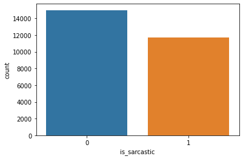

```python
import seaborn as sns #import seaborn
sns.countplot(data['is_sarcastic']) #countplot
print(data['is_sarcastic'].value_counts()) #print values
```

- The dataset has 14985 non-sarcastic headlines and 11724 sarcastic headlines.

### Word Coluds:

- Word Cloud depicting more frequent words

#### Non-Sarcastic Wordcloud

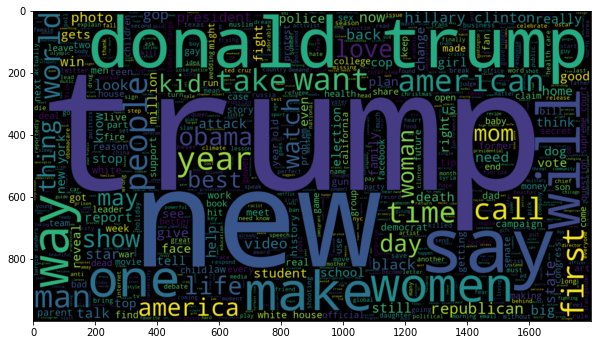

```python
from wordcloud import WordCloud #import Wordcloud
import matplotlib.pyplot as plt
plt.figure(figsize = (10,15)) # Set figure size
cloud = WordCloud(max_words = 800 , width = 1800 , height = 1000) #WordCloud
cloud.generate(" ".join(data[data.is_sarcastic == 0].headline)) #generate WordCloud
plt.imshow(cloud , interpolation = 'bilinear') #print WordCloud
```

#### Sarcastic Wordcloud

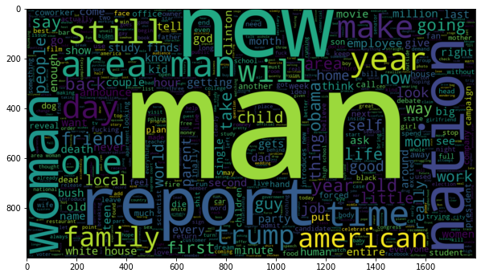

```python
plt.figure(figsize = (10,15)) # Set figure size
cloud = WordCloud(max_words = 800 , width = 1800 , height = 1000) #WordCloud
cloud.generate(" ".join(data[data.is_sarcastic == 1].headline)) #generate WordCloud
plt.imshow(cloud , interpolation = 'bilinear') #print WordCloud
```

### Drop `article_link` from dataset. ( 2 marks)

As we only need headline text data and is_sarcastic column for this project. We can drop artical link column here.

```python
DataFrame = data.drop('article_link',axis=1) #drop article_link
DataFrame.head() #print head
```

|  | headline | is_sarcastic |
| --- | --- | --- |
| 0 | former versace store clerk sues over secret 'b... | 0 |
| 1 | the 'roseanne' revival catches up to our thorn... | 0 |
| 2 | mom starting to fear son's web series closest ... | 1 |
| 3 | boehner just wants wife to listen, not come up... | 1 |
| 4 | j.k. rowling wishes snape happy birthday in th... | 0 |

### Get the Length of each line and find the maximum length. ( 4 marks)

As different lines are of different length. We need to pad the our sequences using the max length.

- Using a lambda function for splitting the headline sentences and finding id and length of headline with maximum length.

```python
DataFrame['length'] = DataFrame['headline'].apply(lambda x: len(x.split(' '))) #lambda function for calculating length of headlines
DataFrame.head() #print head
```

|  | headline | is_sarcastic | length |
| --- | --- | --- | --- |
| 0 | former versace store clerk sues over secret 'b... | 0 | 12 |
| 1 | the 'roseanne' revival catches up to our thorn... | 0 | 14 |
| 2 | mom starting to fear son's web series closest ... | 1 | 14 |
| 3 | boehner just wants wife to listen, not come up... | 1 | 13 |
| 4 | j.k. rowling wishes snape happy birthday in th... | 0 | 11 |

```python
loc = DataFrame['length'].idxmax() #print id of longest headline
max_v = DataFrame['length'].max() #print length of longest headline
print('Maximum value is present at index {id} with maximum length of {val}.'.format(id=loc,val=max_v)) #print
```

```
Maximum value is present at index 15247 with maximum length of 39.
```

```python
DataFrame = DataFrame.drop('length',axis=1) #drop length
DataFrame.head() #print head
```

|  | headline | is_sarcastic |
| --- | --- | --- |
| 0 | former versace store clerk sues over secret 'b... | 0 |
| 1 | the 'roseanne' revival catches up to our thorn... | 0 |
| 2 | mom starting to fear son's web series closest ... | 1 |
| 3 | boehner just wants wife to listen, not come up... | 1 |
| 4 | j.k. rowling wishes snape happy birthday in th... | 0 |

## **Modelling**

### Import required modules required for modelling.

- Importing primary and supporting libraries required for LSTM network.

```python
import numpy as np #import numpy
from tensorflow.keras.preprocessing.text import Tokenizer #import tokenizer
from tensorflow.keras.preprocessing.sequence import pad_sequences #import pad_sequence
from tensorflow.keras.layers import Dense, Input, LSTM, Embedding, Dropout, Activation, Flatten, Bidirectional, GlobalMaxPool1D #import
from tensorflow.keras.models import Model, Sequential #import
```

### Set Different Parameters for the model. ( 2 marks)

- The max features, maximum length and embedding size has been set.

```python
max_features = 10000 #set maximum feature size
maxlen = max_v #set maxlen
embedding_size = 200 #set embedding size
```

### Apply Keras Tokenizer of headline column of your data. ( 4 marks)

- Creating tokens of headlines.

```python
tokenizer = Tokenizer(num_words = max_features) #tokenizer instance
tokenizer.fit_on_texts(DataFrame['headline']) #fit tokenizer
```

### Define X and y for your model.

- Defining X and Y from dataset.

```python
X = tokenizer.texts_to_sequences(DataFrame['headline']) #generate sequence
X = pad_sequences(X, maxlen = maxlen) #create X
y = np.asarray(DataFrame['is_sarcastic']) #create y

print("Number of Samples:", len(X)) #print
print(X[0]) #print
print("Number of Labels: ", len(y)) #print
print(y[0]) #print
```

```
Number of Samples: 26709
[   0    0    0    0    0    0    0    0    0    0    0    0    0    0
    0    0    0    0    0    0    0    0    0    0    0    0    0    0
    0  307  678 3336 2297   47  381 2575    5 2576 8433]
Number of Labels:  26709
0
```

### Get the Vocabulary size ( 2 marks)

- Getting size of vocabulary using tokenizer.word_index

```python
word_index = tokenizer.word_index #get word index
vocab_size = len(word_index) #calculate vocab size
num_words = vocab_size+1 #num_words
print('The size of Vocabulary is {word_i}.'.format(word_i=num_words)) #print
```

```
The size of Vocabulary is 29657.
```

## **Word Embedding**

### Get Glove Word Embeddings

- Loading word embeddings from file.

```python
glove_file = proj_path + "Data/glove.6B.zip" #glove zip file path
```

```python
#Extract Glove embedding zip file
#from zipfile import ZipFile
#with ZipFile(glove_file, 'r') as z:
#  z.extractall()
```

### Get the Word Embeddings using Embedding file as given below.

```python
EMBEDDING_FILE = './glove.6B.200d.txt' #glove embedding file

embeddings = {} #empty dict
for o in open(EMBEDDING_FILE):
    word = o.split(" ")[0] #split
    # print(word)
    embd = o.split(" ")[1:] #split
    embd = np.asarray(embd, dtype='float32')
    # print(embd)
    embeddings[word] = embd
```

### Create a weight matrix for words in training docs

- Creating weight matrix

```python
embedding_matrix = np.zeros((num_words, 200)) #zero matrix

for word, i in tokenizer.word_index.items(): #for loop
    embedding_vector = embeddings.get(word) #embedding vector
    if embedding_vector is not None:
        embedding_matrix[i] = embedding_vector

len(embeddings.values()) #length of embedding values
```

```
400000
```

### Create and Compile your Model ( 7 marks)

- Creating Sequential model instance and then Embedding layer, Bidirectional(LSTM) layer, then dense and dropout layers.
- Adding a Flatten() layer before Final fully connected layer to get a single value as output from the network.
- A final dense layer with sigmoid activation for binary classification.

```python
model = Sequential() #sequential model
model.add(Input(shape=(maxlen,)))
model.add(Embedding(num_words, embedding_size, weights = [embedding_matrix])) #Embedding layer
model.add(Bidirectional(LSTM(128, return_sequences = True, recurrent_dropout=0.1))) #Bi-directional LSTM layer with 128 units
model.add(Dropout(0.1)) #Dropout layer
model.add(Dense(128,activation='relu')) #Dense layer with relu activation
model.add(Dropout(0.1)) #Dropout layer
model.add(Dense(64,activation='relu')) #Dense layer with relu activation
model.add(Dropout(0.1)) #Dropout layer
model.add(Dense(32,activation='relu')) #Dense layer with relu activation
model.add(Dropout(0.1)) #Dropout layer
model.add(Dense(16,activation='relu')) #Dense layer with relu activation
model.add(Dropout(0.2)) #Dropout layer
model.add(Flatten()) #Flatten layer
model.add(Dense(1,activation='sigmoid')) #Dense layer with sigmoid activation
model.compile(optimizer='adam',loss='binary_crossentropy',metrics=['accuracy']) #Compile
model.summary() #Summary
```

```
WARNING:tensorflow:Layer lstm will not use cuDNN kernel since it doesn't meet the cuDNN kernel criteria. It will use generic GPU kernel as fallback when running on GPU
WARNING:tensorflow:Layer lstm will not use cuDNN kernel since it doesn't meet the cuDNN kernel criteria. It will use generic GPU kernel as fallback when running on GPU
WARNING:tensorflow:Layer lstm will not use cuDNN kernel since it doesn't meet the cuDNN kernel criteria. It will use generic GPU kernel as fallback when running on GPU
Model: "sequential"
_________________________________________________________________
Layer (type)                 Output Shape              Param #
=================================================================
embedding (Embedding)        (None, 39, 200)           5931400
_________________________________________________________________
bidirectional (Bidirectional (None, 39, 256)           336896
_________________________________________________________________
dropout (Dropout)            (None, 39, 256)           0
_________________________________________________________________
dense (Dense)                (None, 39, 128)           32896
_________________________________________________________________
dropout_1 (Dropout)          (None, 39, 128)           0
_________________________________________________________________
dense_1 (Dense)              (None, 39, 64)            8256
_________________________________________________________________
dropout_2 (Dropout)          (None, 39, 64)            0
_________________________________________________________________
dense_2 (Dense)              (None, 39, 32)            2080
_________________________________________________________________
dropout_3 (Dropout)          (None, 39, 32)            0
_________________________________________________________________
dense_3 (Dense)              (None, 39, 16)            528
_________________________________________________________________
dropout_4 (Dropout)          (None, 39, 16)            0
_________________________________________________________________
flatten (Flatten)            (None, 624)               0
_________________________________________________________________
dense_4 (Dense)              (None, 1)                 625
=================================================================
Total params: 6,312,681
Trainable params: 6,312,681
Non-trainable params: 0
_________________________________________________________________
```

### Fit your model with a batch size of 100 and validation_split = 0.2. and state the validation accuracy ( 5 marks)

- Fitting model with given parameters.

```python
batch_size = 100 #batch size
epochs = 3 #epoch
model_H = model.fit(X,y,epochs=epochs,batch_size=batch_size,validation_split = 0.2) #fit model and create history object
```

- **Validation accuracy is around 86% after 3 epochs.**

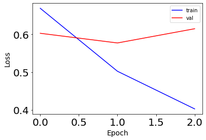

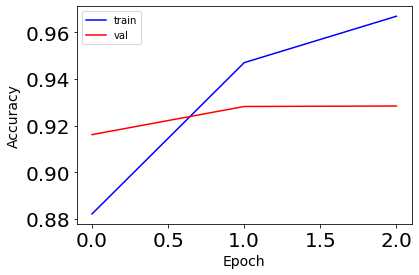

```python
import matplotlib.pyplot as plt #import pyplot
# Plot the loss function
fig, ax = plt.subplots(1, 1, figsize=(6,4)) #Create subplots
ax.plot(np.sqrt(model_H.history['loss']), 'b', label='train') #Plot training loss
ax.plot(np.sqrt(model_H.history['val_loss']), 'r' ,label='val') #Plot validation loss
ax.set_xlabel(r'Epoch', fontsize=14) #set xlabel
ax.set_ylabel(r'Loss', fontsize=14) #set ylabel
ax.legend() #set legend
ax.tick_params(labelsize=20) #set label size

# Plot the accuracy
fig, ax = plt.subplots(1, 1, figsize=(6,4)) #Create subplots
ax.plot(np.sqrt(model_H.history['accuracy']), 'b', label='train') #Plot training accuracy
ax.plot(np.sqrt(model_H.history['val_accuracy']), 'r' ,label='val') #Plot validation accuracy
ax.set_xlabel(r'Epoch', fontsize=14) #set xlabel
ax.set_ylabel(r'Accuracy', fontsize=14) #set ylabel
ax.legend() #set legend
ax.tick_params(labelsize=20) #set label size
```

- The Training accuracy is higher than validation because the network is slightly overfitting. While, Training loss has decreased per epoch the validation loss has been constant.

## Sample Predictions:

- Below are sample predictions generated from the network for sample headlines which are not present in the dataset.

```python
headline = ['How a simple breathing trick can change your life'] #Sample Headline
headline = tokenizer.texts_to_sequences(headline) #Tokenize
headline = pad_sequences(headline, maxlen=maxlen, dtype='int32', value=0) #pad_sequence

sarcasm = model.predict(headline,batch_size=1,verbose = 2) #Predict
sarcasm1 = np.round(sarcasm) #Round predictions
if(sarcasm1 == 0): #check if non-sarcastic
    print("The headline is Not-sarcastic.")
elif (sarcasm1 == 1): #check if sarcastic
    print("The headline is sarcastic.")
```

```
1/1 - 0s
The headline is Not-sarcastic.
```

```python
headline = ['safety meeting ends in accident'] #Sample Headline
headline = tokenizer.texts_to_sequences(headline) #Tokenize
headline = pad_sequences(headline, maxlen=maxlen, dtype='int32', value=0) #pad_sequence

sarcasm_test = model.predict(headline,batch_size=1,verbose = 2) #Predict
sarcasm_test1 = np.round(sarcasm_test) #Round predictions
if(sarcasm_test1 == 0): #check if non-sarcastic
    print("The headline is Not-sarcastic.")
elif (sarcasm_test1 == 1): #check if sarcastic
    print("The headline is sarcastic.")
```

```
1/1 - 0s
The headline is sarcastic.
```

## Comments

- All insights, important observations and performed steps have already been added below every step. These are some concluding comments.

### Comments on Dataset

- The dataset had 26709 rows and 3 columns.
- The vocabulary size became 29657 after calculating.
- Maximum length of a headline is 39 words.

### Miscellaneous Comments

- The predictions performed for sarcastic and non-sarcaastic headlines are not in the dataset, they are collected from internet.